# act_report

## Report: act_report

- Create a **250-word-minimum written report** called "act_report.pdf" or "act_report.html" that communicates the insights and displays the visualization(s) produced from your wrangled data. This is to be framed as an external document, like a blog post or magazine article, for example.

Additionally, majority of the ratings fall between $0$ to $14$ inclusive. Ratings above $14$ do not have more than one dog with that rating and the total number of dogs in the dataset with rating above $14$ are $20$ in total. This suggests some bias towards those dogs or extremely endearing qualities that could earn them those ratings. Better still, the tripple digit ratings were data entry errors.

It is also observed that all three image prediction algorithms, p1,p2 and p3 had more than $500$ false predictions and a $1000+$ true predictions, with p2 doing slightly better than the others.

Overall the rating process does not appear to follow any laid down procedure. It is subject to the rater's dispostion.

The image below shows the plot of the count of the dag stages and their frequency in the dataset

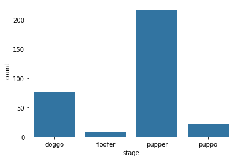